# Chapter 6 - MDS: computer exercises

Author

Prof. Richard Wilkinson

### Task 1

The `eurodist` dataset in R gives the road distances between 21 European cities.

1. Perform multidimensional scaling on this data, and find a two-dimensional set of points which has interpoint distances approximately equal to the data.

**Solution**

```r
data(eurodist)
eurodist
```

```
                Athens Barcelona Brussels Calais Cherbourg Cologne Copenhagen
Barcelona         3313
Brussels          2963      1318
Calais            3175      1326      204
Cherbourg         3339      1294      583    460
Cologne           2762      1498      206    409       785
Copenhagen        3276      2218      966   1136      1545     760
Geneva            2610       803      677    747       853    1662       1418
Gibraltar         4485      1172     2256   2224      2047    2436       3196
Hamburg           2977      2018      597    714      1115     460        460
Hook of Holland   3030      1490      172    330       731     269        269
Lisbon            4532      1305     2084   2052      1827    2290       2971
Lyons             2753       645      690    739       789     714       1458
Madrid            3949       636     1558   1550      1347    1764       2498
Marseilles        2865       521     1011   1059      1101    1035       1778
Milan             2282      1014      925   1077      1209     911       1537
Munich            2179      1365      747    977      1160     583       1104
Paris             3000      1033      285    280       340     465       1176
Rome               817      1460     1511   1662      1794    1497       2050
Stockholm         3927      2868     1616   1786      2196    1403        650
Vienna            1991      1802     1175   1381      1588     937       1455
                Geneva Gibraltar Hamburg Hook of Holland Lisbon Lyons Madrid
Barcelona
Brussels
Calais
Cherbourg
Cologne
Copenhagen
Geneva
Gibraltar         1975
Hamburg           1118      2897
Hook of Holland    895      2428     550
Lisbon            1936       676    2671            2280
Lyons              158      1817    1159             863   1178
Madrid            1439       698    2198            1730    668  1281
Marseilles         425      1693    1479            1183   1762   320   1157
Milan              328      2185    1238            1098   2250   328   1724
Munich             591      2565     805             851   2507   724   2010
Paris              513      1971     877             457   1799   471   1273
Rome               995      2631    1751            1683   2700  1048   2097
```

[output cut: 8 more lines]

```
Copenhagen
Geneva
Gibraltar
Hamburg
Hook of Holland
Lisbon
Lyons
Madrid
Marseilles
Milan                  618
Munich                1109   331
Paris                  792   856    821
Rome                  1011   586    946  1476
Stockholm             2428  2187   1754  1827 2707
Vienna                1363   898    428  1249 1209      2105
```

```r
?eurodist
eurodist.mds <- cmdscale(eurodist)  # k=2 by default
```

2. Plot these coordinates and label them with the city names. Does your plot look like the map of Europe?

**Solution**

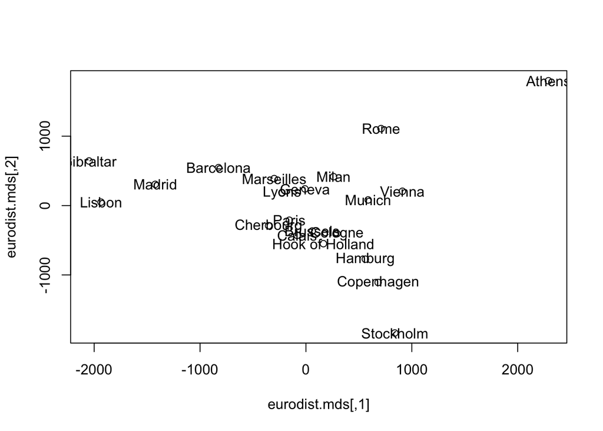

```r
plot(eurodist.mds)
text(eurodist.mds, labels = row.names(eurodist.mds))
```

This has put labels on top of each other making it difficult to read. We can use ggplot2 and the ggrepel package to create a more elegant plot, but first we have to create a data frame.

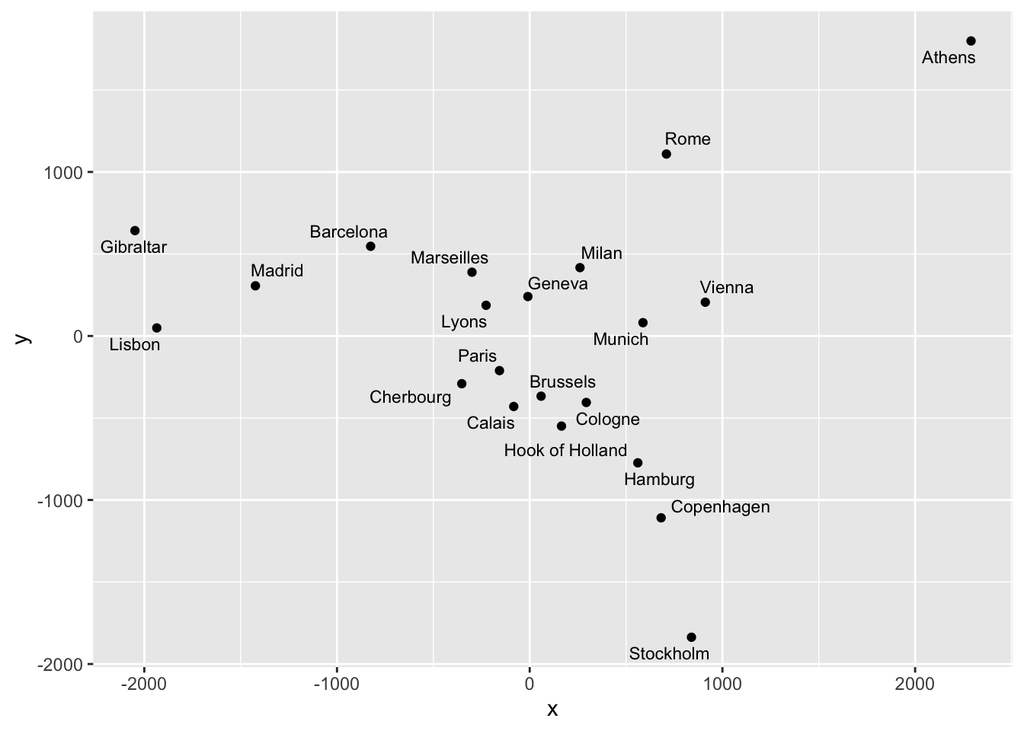

```r
library(ggplot2)
library(ggrepel)
coords = data.frame(x=eurodist.mds[,1], y=eurodist.mds[,2])

ggplot(coords, aes(x=x, y=y)) +
    geom_point() +
  geom_text_repel(aes(label = row.names(eurodist.mds)), size = 3)
```

This is upside down, so let’s multiply the y-axis by -1.

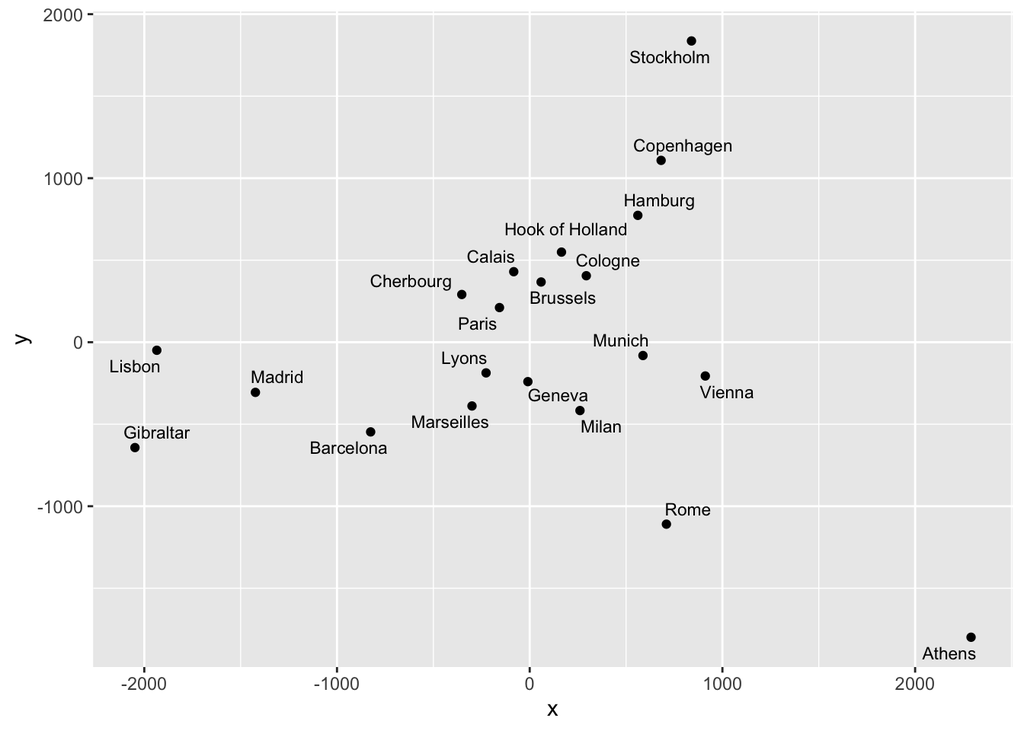

```r
coords = data.frame(x=eurodist.mds[,1], y=-1*eurodist.mds[,2])
ggplot(coords, aes(x=x, y=y)) +
    geom_point() +
  geom_text_repel(aes(label = row.names(eurodist.mds)), size = 3)
```

```r
#plot(tmp, cex=0)
#text(tmp, labels = row.names(eurodist.mds), cex=0.4)
# shrink
```

The rotation is still a little off but we can see that most of the cities are roughly in the right place.

3. Is the distance matrix `eurodist` a Euclidean data matrix and how do you know? If it is not Euclidean, why do you think that might be?

**Solution**

```r
cmdscale(eurodist, eig = TRUE)
```

```
$points
                        [,1]        [,2]
Athens           2290.274680  1798.80293
Barcelona        -825.382790   546.81148
Brussels           59.183341  -367.08135
Calais            -82.845973  -429.91466
Cherbourg        -352.499435  -290.90843
Cologne           293.689633  -405.31194
Copenhagen        681.931545 -1108.64478
Geneva             -9.423364   240.40600
Gibraltar       -2048.449113   642.45854
Hamburg           561.108970  -773.36929
Hook of Holland   164.921799  -549.36704
Lisbon          -1935.040811    49.12514
Lyons            -226.423236   187.08779
Madrid          -1423.353697   305.87513
Marseilles       -299.498710   388.80726
Milan             260.878046   416.67381
Munich            587.675679    81.18224
Paris            -156.836257  -211.13911
Rome              709.413282  1109.36665
Stockholm         839.445911 -1836.79055
Vienna            911.230500   205.93020

$eig
 [1]  1.953838e+07  1.185656e+07  1.528844e+06  1.118742e+06  7.893472e+05
 [6]  5.816552e+05  2.623192e+05  1.925976e+05  1.450845e+05  1.079673e+05
[11]  5.139484e+04 -3.725290e-09 -9.496124e+03 -5.305820e+04 -1.322166e+05
[16] -2.573360e+05 -3.326719e+05 -5.162523e+05 -9.191491e+05 -1.006504e+06
[21] -2.251844e+06

$x
NULL

$ac
[1] 0

$GOF
[1] 0.7537543 0.8679134
```

So there are significant negative eigenvalues for the distance matrix. This is because the distances are distance by road, not Euclidean distance. Over the scale of the continent, the Earth’s curvature would also have a small effect.

4. Create the Euclidean distance matrix from your set of 2-dimensional points. What is the Frobenius norm between this matrix and the original distance matrix? Use `cmdscale` to create a set of points in 3 dimensional space and recompute the distance matrix.

**Solution**

The Frobenius norm of a matrix is the square root of the sum of the elements squared. We only have a lower diagonal matrix, and so we need to multiply the sum by 2.

```r
dist1 <- dist(eurodist.mds)
dist2 <- dist(cmdscale(eurodist, k=3), diag=TRUE, upper = TRUE)
sqrt(sum((eurodist-dist1)^2)*2)
```

```
[1] 3236.514
```

```r
sqrt(sum((eurodist-dist2)^2)*2)# use 3 dimensions
```

```
[1] 3202.471
```

So using 3 components has slightly reduced the error, but not by much.

### Task 2

Consider the synthetic data of 9 binary attributes on 11 cases.

```r
df=structure(list(a = c(0, 0, 0, 0, 1, 0, 0, 1, 0, 0, 0), b = c(0,
0, 0, 0, 0, 0, 1, 0, 1, 0, 1), c = c(0, 0, 0, 0, 1, 0, 0, 1,
0, 1, 0), d = c(1, 0, 0, 0, 0, 0, 1, 0, 0, 1, 0), e = c(0, 0,
1, 0, 0, 0, 0, 0, 0, 0, 1), f = c(0, 0, 1, 0, 0, 0, 0, 0, 0,
0, 1), g = c(0, 1, 1, 1, 0, 0, 0, 0, 0, 0, 0), h = c(1, 0, 0,
0, 0, 0, 0, 1, 1, 0, 0), i = c(0, 0, 0, 0, 0, 1, 0, 0, 1, 1,
0)), class = "data.frame", row.names = c(NA, -11L), .Names = c("a",
"b", "c", "d", "e", "f", "g", "h", "i"))
df
```

```
   a b c d e f g h i
1  0 0 0 1 0 0 0 1 0
2  0 0 0 0 0 0 1 0 0
3  0 0 0 0 1 1 1 0 0
4  0 0 0 0 0 0 1 0 0
5  1 0 1 0 0 0 0 0 0
6  0 0 0 0 0 0 0 0 1
7  0 1 0 1 0 0 0 0 0
8  1 0 1 0 0 0 0 1 0
9  0 1 0 0 0 0 0 1 1
10 0 0 1 1 0 0 0 0 1
11 0 1 0 0 1 1 0 0 0
```

1. Compute the Jaccard index and SMC similarity matrices for these data.

**Solution**

```r
(F_Jacc <- 1-as.matrix(dist(df, method="binary", diag=TRUE, upper=TRUE)))
```

```
           1         2         3         4         5         6         7
1  1.0000000 0.0000000 0.0000000 0.0000000 0.0000000 0.0000000 0.3333333
2  0.0000000 1.0000000 0.3333333 1.0000000 0.0000000 0.0000000 0.0000000
3  0.0000000 0.3333333 1.0000000 0.3333333 0.0000000 0.0000000 0.0000000
4  0.0000000 1.0000000 0.3333333 1.0000000 0.0000000 0.0000000 0.0000000
5  0.0000000 0.0000000 0.0000000 0.0000000 1.0000000 0.0000000 0.0000000
6  0.0000000 0.0000000 0.0000000 0.0000000 0.0000000 1.0000000 0.0000000
7  0.3333333 0.0000000 0.0000000 0.0000000 0.0000000 0.0000000 1.0000000
8  0.2500000 0.0000000 0.0000000 0.0000000 0.6666667 0.0000000 0.0000000
9  0.2500000 0.0000000 0.0000000 0.0000000 0.0000000 0.3333333 0.2500000
10 0.2500000 0.0000000 0.0000000 0.0000000 0.2500000 0.3333333 0.2500000
11 0.0000000 0.0000000 0.5000000 0.0000000 0.0000000 0.0000000 0.2500000
           8         9        10   11
1  0.2500000 0.2500000 0.2500000 0.00
2  0.0000000 0.0000000 0.0000000 0.00
3  0.0000000 0.0000000 0.0000000 0.50
4  0.0000000 0.0000000 0.0000000 0.00
5  0.6666667 0.0000000 0.2500000 0.00
6  0.0000000 0.3333333 0.3333333 0.00
7  0.0000000 0.2500000 0.2500000 0.25
8  1.0000000 0.2000000 0.2000000 0.00
9  0.2000000 1.0000000 0.2000000 0.20
10 0.2000000 0.2000000 1.0000000 0.00
11 0.0000000 0.2000000 0.0000000 1.00
```

```r
(F_SMC <- (dim(df)[2]-as.matrix(dist(df, method="manhattan", diag = TRUE, upper = TRUE)))/dim(df)[2])
```

```
           1         2         3         4         5         6         7
1  1.0000000 0.6666667 0.4444444 0.6666667 0.5555556 0.6666667 0.7777778
2  0.6666667 1.0000000 0.7777778 1.0000000 0.6666667 0.7777778 0.6666667
3  0.4444444 0.7777778 1.0000000 0.7777778 0.4444444 0.5555556 0.4444444
4  0.6666667 1.0000000 0.7777778 1.0000000 0.6666667 0.7777778 0.6666667
5  0.5555556 0.6666667 0.4444444 0.6666667 1.0000000 0.6666667 0.5555556
6  0.6666667 0.7777778 0.5555556 0.7777778 0.6666667 1.0000000 0.6666667
7  0.7777778 0.6666667 0.4444444 0.6666667 0.5555556 0.6666667 1.0000000
8  0.6666667 0.5555556 0.3333333 0.5555556 0.8888889 0.5555556 0.4444444
9  0.6666667 0.5555556 0.3333333 0.5555556 0.4444444 0.7777778 0.6666667
10 0.6666667 0.5555556 0.3333333 0.5555556 0.6666667 0.7777778 0.6666667
11 0.4444444 0.5555556 0.7777778 0.5555556 0.4444444 0.5555556 0.6666667
           8         9        10        11
1  0.6666667 0.6666667 0.6666667 0.4444444
2  0.5555556 0.5555556 0.5555556 0.5555556
3  0.3333333 0.3333333 0.3333333 0.7777778
4  0.5555556 0.5555556 0.5555556 0.5555556
5  0.8888889 0.4444444 0.6666667 0.4444444
6  0.5555556 0.7777778 0.7777778 0.5555556
7  0.4444444 0.6666667 0.6666667 0.6666667
8  1.0000000 0.5555556 0.5555556 0.3333333
9  0.5555556 1.0000000 0.5555556 0.5555556
10 0.5555556 0.5555556 1.0000000 0.3333333
11 0.3333333 0.5555556 0.3333333 1.0000000
```

2. Perform classical MDS for both similarity matrices, producing a plot of the coordinates (in 2d). Are the results similar?

**Solution**

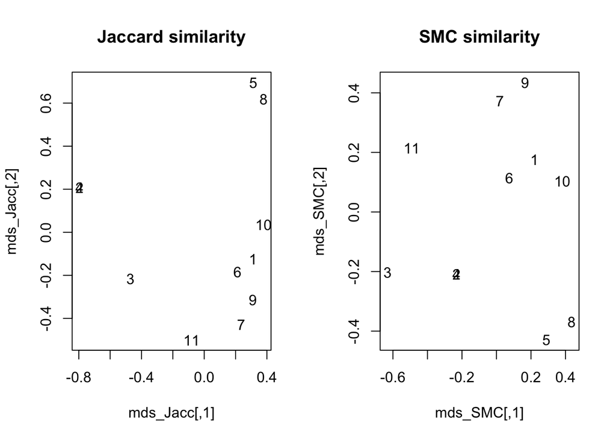

```r
FtoD <- function(FF){
  n = dim(FF)[1]
  D <- matrix(nr=n,nc=n)
  for(ii in 1:n){
    for(jj in 1:n){
      D[ii,jj] <- sqrt(FF[ii,ii]+FF[jj,jj]-2*FF[ii,jj])
    }
  }
  return(D)
}

mds_Jacc <- cmdscale(FtoD(F_Jacc))
mds_SMC <- cmdscale(FtoD(F_SMC))

par(mfrow=c(1,2))
plot(mds_Jacc,cex=0, main="Jaccard similarity")
text(mds_Jacc,label=1:11)
plot(mds_SMC,cex=0, main="SMC similarity")
text(mds_SMC,label=1:11)
```

### Task 3

In this question we will look at data from 1888 on the fertility and socio-economic status of 47 French speaking provinces in Switzerland.

1. Compute the Euclidean distance matrix for these data.

**Solution**

```r
data(swiss)
dist(swiss)
```

2. Use MDS to create a 2-dimensional representation of the data and plot these points, labelling them with the province name.

**Solution**

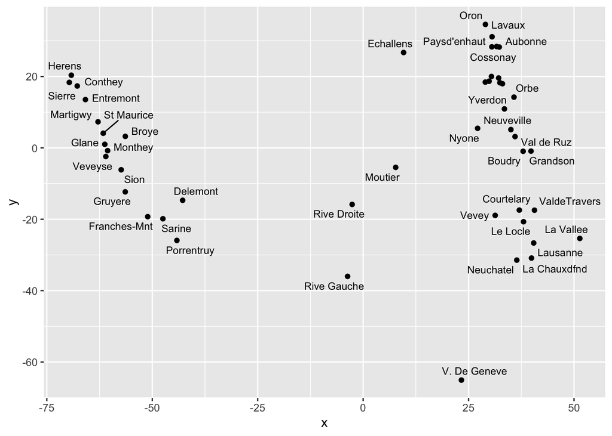

```r
library(dplyr)
library(ggpubr) # repels figure labels
# Compute MDS
mds <- swiss |>  dist() |>
  cmdscale() |> data.frame()
colnames(mds) <- c("x", "y")

ggplot(mds, aes(x=x, y=y)) +
    geom_point() +
  geom_text_repel(aes(label = row.names(swiss)), size = 3)
```

3. Use MDS to create a 3-dimensional representation of the data.

**Solution**

```r
mds3 <- swiss |>
  dist() |>
  cmdscale(k=3) |> data.frame()

library(rgl)
plot3d(mds3)
```

`plot3d` should create a pop-up window that you can then manually rotate.

4. MDS can be also used to reveal a hidden pattern in a correlation matrix. Find the correlation matrix, $\mathbf R$, of the swiss data. Perform MDS using $1-\mathbf R$ as the distance matrix and plot the results. Positively correlated covariates are close together on the same side of the plot.

**Solution**

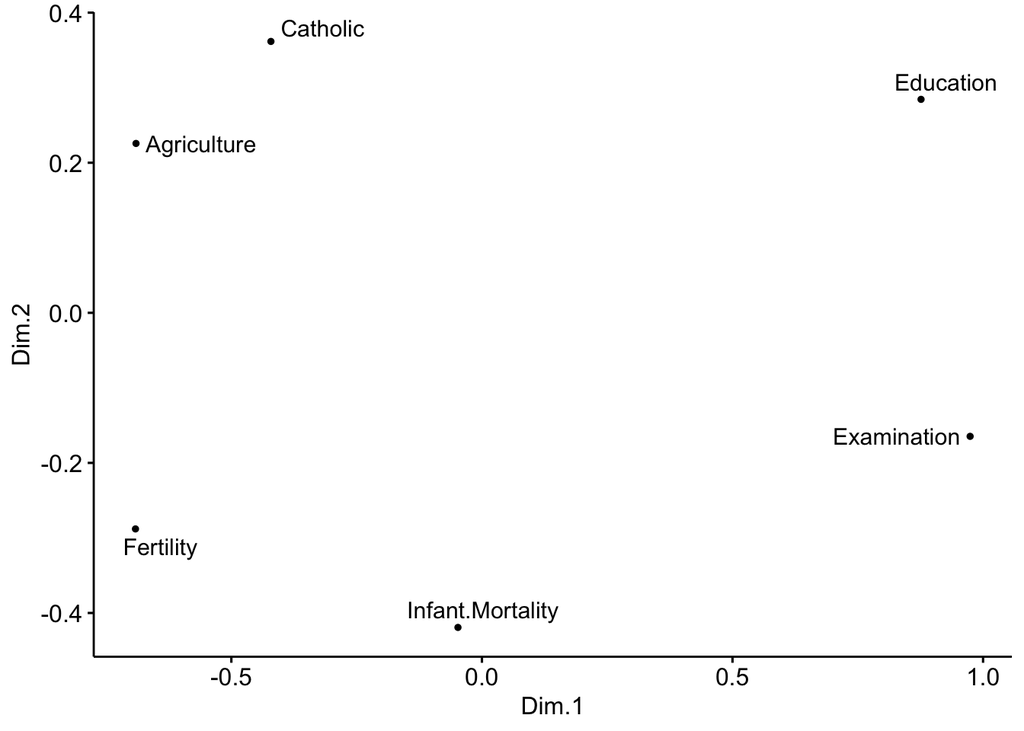

```r
D=1-cor(swiss)
mdsR <- D |> cmdscale() |> data.frame()
colnames(mdsR) <- c("Dim.1", "Dim.2")
# Plot MDS
ggscatter(mdsR, x = "Dim.1", y = "Dim.2",
          label=colnames(swiss),
          size = 1,
          repel = TRUE)
```

### Task 4

Try MDS on the MNIST data but looking for a 3d representation. Colour the points by their digit label, and create some interactive 3d plots. Does this find useful structure in the data? And is it more informative than the 2d plots we created in the notes.

**Solution**

```r
load('../Notes_bookdown/Bookdown/mnist.rda')
X<- mnist$train$x[1:1000,] # select juist the first 1000 images
Digits <- mnist$train$y[1:1000]
Y<- (X>0.3)*1.  # convert intensities to binary
# multiply by 1 to convert from T/F to a 1/0

n=dim(Y)[1]
p=dim(Y)[2]

F_SMC=(p-as.matrix(dist(Y, method="manhattan", diag = TRUE, upper = TRUE)))/p
F_Jaccard = 1-as.matrix(dist(Y, method="binary", diag=TRUE, upper=TRUE))

mds1=data.frame(cmdscale(FtoD(F_SMC), k = 3))
mds2=data.frame(cmdscale(FtoD(F_Jaccard), k = 3))
```

The `rgl` package creates interactive plots you can manipulate.

```r
library(rgl)
plot3d(mds1, col=Digits+1)
plot3d(mds2, col=Digits+1)
```

The `plotly` package creates interactive plots. Try the following:

```r
library(plotly)

mds1$digit <- as.factor(Digits)
# so that we get a discrete colour scheme

fig <- plot_ly(mds1, x = ~X1, y = ~X2, z = ~X3, color = ~digit)#, colors = c('#BF382A', '#0C4B8E'))
fig <- fig |> add_markers(size=5)
fig


mds2$digit <- as.factor(Digits)
# so that we get a discrete colour scheme

fig2 <- plot_ly(mds2, x = ~X1, y = ~X2, z = ~X3, color = ~digit)#, colors = c('#BF382A', '#0C4B8E'))
fig2 <- fig2 |> add_markers(size=5)
fig2
```

Read the description of more advanced methods [here](https://colah.github.io/posts/2014-10-Visualizing-MNIST/). Pick one and find an R package that implements it and try it on the MNIST data.